# Gradient Visualization using Seaborn, Matplotlib, and Plotly

This notebook demonstrates how to visualize the gradient of a function using various Python libraries such as Seaborn, Matplotlib, and Plotly.

## What is a Gradient?

The gradient of a function is a vector that points in the direction of the greatest rate of increase of the function. For a function $f(x, y)$, the gradient is defined as:

$$ \nabla f = \left( \frac{\partial f}{\partial x}, \frac{\partial f}{\partial y} \right) $$

The gradient always points in the direction of the steepest ascent of the function at a given point, and its magnitude represents the rate of change of the function in that direction.

Some key properties and applications of the gradient:

- The gradient is perpendicular to the level curves (or level surfaces in higher dimensions) of the function at any point.
- Direction of steepest ascent: The gradient vector points in the direction of the steepest ascent of the function at a given point. This means that if you move in the direction of the gradient, the function value will increase at the fastest rate possible.
- Zero gradient: If the gradient vector is zero at a point, i.e., $\nabla f = \mathbf{0}$, then the point is called a stationary point or critical point. At a stationary point, the function may have a local maximum, local minimum, or saddle point.
- In physics, the negative of the gradient of a potential function gives the direction and magnitude of the force associated with that potential.
- The gradient is a fundamental concept in vector calculus and has applications in various fields, including physics, engineering, and machine learning.
- Linearity:
  - Addition: For two scalar-valued functions $f(x_1, x_2, \ldots, x_n)$ and $g(x_1, x_2, \ldots, x_n)$, the gradient of their sum is equal to the sum of their individual gradients: $\nabla(f + g) = \nabla f + \nabla g$
  - Scalar multiplication: For a scalar-valued function $f(x_1, x_2, \ldots, x_n)$ and a constant $c$, the gradient of the product $cf$ is equal to the product of $c$ and the gradient of $f$: $\nabla(cf) = c\nabla f$
- Product rule: For two scalar-valued functions $f(x_1, x_2, \ldots, x_n)$ and $g(x_1, x_2, \ldots, x_n)$, the gradient of their product is given by: $\nabla(fg) = f\nabla g + g\nabla f$
- Chain rule: If $f(x_1, x_2, \ldots, x_n)$ is a scalar-valued function and each $x_i$ is a function of variables $t_1, t_2, \ldots, t_m$, then the gradient of $f$ with respect to $t_1, t_2, \ldots, t_m$ is given by: $\nabla_{\mathbf{t}} f = \left(\frac{\partial f}{\partial x_1}\frac{\partial x_1}{\partial t_1} + \frac{\partial f}{\partial x_2}\frac{\partial x_2}{\partial t_1} + \ldots + \frac{\partial f}{\partial x_n}\frac{\partial x_n}{\partial t_1}, \ldots, \frac{\partial f}{\partial x_1}\frac{\partial x_1}{\partial t_m} + \frac{\partial f}{\partial x_2}\frac{\partial x_2}{\partial t_m} + \ldots + \frac{\partial f}{\partial x_n}\frac{\partial x_n}{\partial t_m}\right)$
- Conservative vector fields: A vector field $\mathbf{F}(x_1, x_2, \ldots, x_n) = (F_1, F_2, \ldots, F_n)$ is called conservative if there exists a scalar-valued function $f(x_1, x_2, \ldots, x_n)$ such that: $\nabla f = \mathbf{F}$. In other words, a conservative vector field is the gradient of some scalar-valued function.
- Curl: The curl of the gradient of any scalar-valued function is always zero: $\nabla \times (\nabla f) = \mathbf{0}$. This property is a consequence of the fact that the gradient is a conservative vector field.

## Level Curves

Level curves, also known as contour lines or isolines, are curves along which a function has a constant value. In other words, if $ f(x, y) $ is a two-variable function, then a level curve is a curve in the xy-plane on which $ f(x, y) = c $, where c is a constant.

Properties of level curves:

- Different level curves correspond to different constant values of the function.
- Level curves do not intersect each other, as a function cannot have two different values at the same point.
- The gradient vector $\nabla f$ is always perpendicular to the level curve at any point.
- The spacing between level curves can indicate the rate of change of the function. Closely spaced level curves indicate a rapid change in the function value, while widely spaced level curves indicate a slow change.

In this notebook, we will visualize the gradients of the following functions:

- $f_1(x, y) = x^2 + y^2$
- $f_2(x, y) = x^3 - 3xy + y^3$

We will compute the gradients and visualize them using both 2D and 3D plots.

## Import Libraries

First, we import the necessary libraries for our visualizations.

```python
import seaborn as sns
import matplotlib.pyplot as plt
import numpy as np
from mpl_toolkits.mplot3d import Axes3D
import plotly.graph_objects as go
import sympy as sp
```

## Symbolic Differentiation using SymPy

We use SymPy to compute the gradient of the following functions symbolically:

- $f_1(x, y) = x^2 + y^2$
- $f_2(x, y) = x^3 - 3xy + y^3$

```python
# Define the variables
x, y = sp.symbols('x y')

# Define the function 1
f1 = x**2 + y**2

# Define the function 2
f2 = x**3 - 3*x*y + y**3

# Compute the gradient for function 1
grad_f1 = [sp.diff(f1, var) for var in (x, y)]
grad_f1 = sp.Matrix(grad_f1)

# Print the gradient for function 1
print("Gradient of f1:", grad_f1)

# Evaluate the gradient for function 1 at a specific point
grad_f1_at_point = grad_f1.subs({x: 1, y: 2})
print("Gradient of f1 at (x, y) = (1, 2):", grad_f1_at_point)

# Compute the gradient for function 2
grad_f2 = [sp.diff(f2, var) for var in (x, y)]
grad_f2 = sp.Matrix(grad_f2)

# Print the gradient for function 2
print("Gradient of f2:", grad_f2)

# Evaluate the gradient for function 2 at a specific point
grad_f2_at_point = grad_f2.subs({x: 1, y: 2})
print("Gradient of f2 at (x, y) = (1, 2):", grad_f2_at_point)
```

```
Gradient of f1: Matrix([[2*x], [2*y]])
Gradient of f1 at (x, y) = (1, 2): Matrix([[2], [4]])
Gradient of f2: Matrix([[3*x**2 - 3*y], [-3*x + 3*y**2]])
Gradient of f2 at (x, y) = (1, 2): Matrix([[-3], [9]])
```

## Define Functions and Gradients

We define the functions $ f_1(x, y) = x^2 + y^2 $ and $ f_2(x, y) = x^3 - 3xy + y^3 $, along with their gradients.

- **Functions**:
  - $ f_1(x, y) = x^2 + y^2 $
  - $ f_2(x, y) = x^3 - 3xy + y^3 $
- **Gradients**:
  - The gradient of $ f_1 $ is given by: $$ \nabla f_1 = \left( 2x, 2y \right) $$
  - The gradient of $ f_2 $ is given by: $$ \nabla f_2 = \left( 3x^2 - 3y, 3y^2 - 3x \right) $$

```python
# Define the functions and their gradients
def f1(x, y):
    return x**2 + y**2

def grad_f1(x, y):
    return np.array([2*x, 2*y])

def f2(x, y):
    return x**3 - 3*x*y + y**3

def grad_f2(x, y):
    return np.array([3*x**2 - 3*y, 3*y**2 - 3*x])
```

```python
# Create a grid of points
x = np.linspace(-3, 3, 60)
y = np.linspace(-3, 3, 60)
X, Y = np.meshgrid(x, y)
```

```python
# Compute the function values
Z1 = f1(X, Y)
Z2 = f2(X, Y)
```

```python
# Compute the gradients
U1, V1 = grad_f1(X, Y)
U2, V2 = grad_f2(X, Y)
```

## 2D Contour Plots using Matplotlib

We create 2D contour plots of the functions and overlay the gradient vectors.

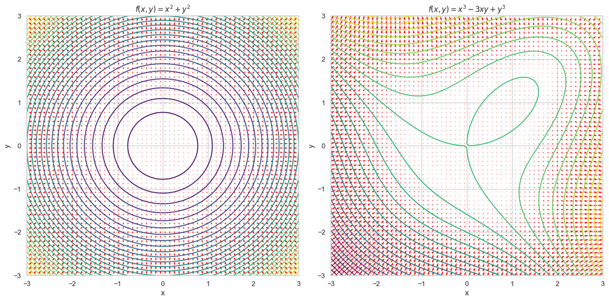

```python
# Create the plots
fig, (ax1, ax2) = plt.subplots(1, 2, figsize=(14, 7))

#IMPORTANT: The quiver function automatically scales the vectors.
# Plot for f1
ax1.contour(X, Y, Z1, levels=30, cmap='viridis')
ax1.quiver(X, Y, U1, V1, color='red')
ax1.set_title(r'$f(x, y) = x^2 + y^2$')
ax1.set_xlabel('x')
ax1.set_ylabel('y')

# Plot for f2
ax2.contour(X, Y, Z2, levels=30, cmap='viridis')
ax2.quiver(X, Y, U2, V2, color='red')
ax2.set_title(r'$f(x, y) = x^3 - 3xy + y^3$')
ax2.set_xlabel('x')
ax2.set_ylabel('y')

plt.tight_layout()
plt.show()
```

## 2D Contour Plots using Seaborn

We create similar 2D contour plots using Seaborn for improved aesthetics.

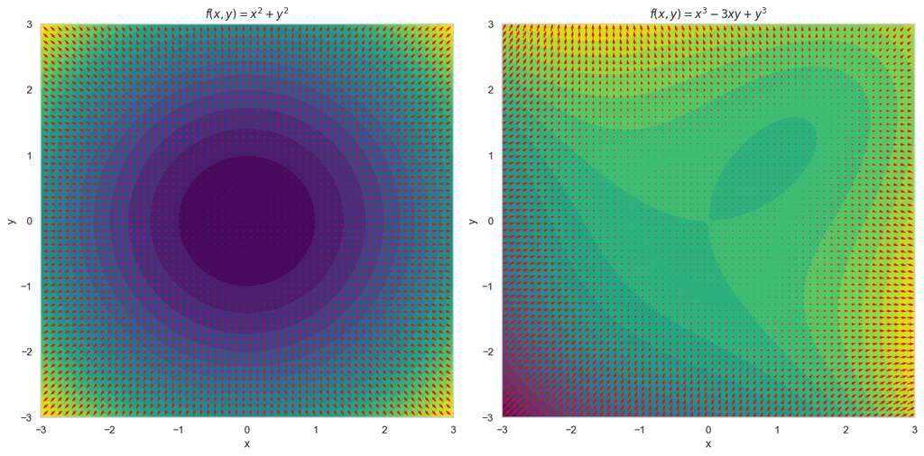

```python
# Seaborn Plot
fig_seaborn, (ax1_sns, ax2_sns) = plt.subplots(1, 2, figsize=(14, 7))

# Seaborn Plot for f1
sns.set(style="whitegrid")
contour1_sns = ax1_sns.contourf(X, Y, Z1, levels=20, cmap='viridis')
ax1_sns.quiver(X, Y, U1, V1, color='red')
ax1_sns.set_title(r'$f(x, y) = x^2 + y^2$')
ax1_sns.set_xlabel('x')
ax1_sns.set_ylabel('y')

# Seaborn Plot for f2
contour2_sns = ax2_sns.contourf(X, Y, Z2, levels=20, cmap='viridis')
ax2_sns.quiver(X, Y, U2, V2, color='red')
ax2_sns.set_title(r'$f(x, y) = x^3 - 3xy + y^3$')
ax2_sns.set_xlabel('x')
ax2_sns.set_ylabel('y')

plt.tight_layout()
plt.show()
```

## 3D Plot using Matplotlib

We create a 3D surface plot of the function $ f_1 \left(x,y\right) = x^2 + y^2 $ and overlay the gradient vectors.

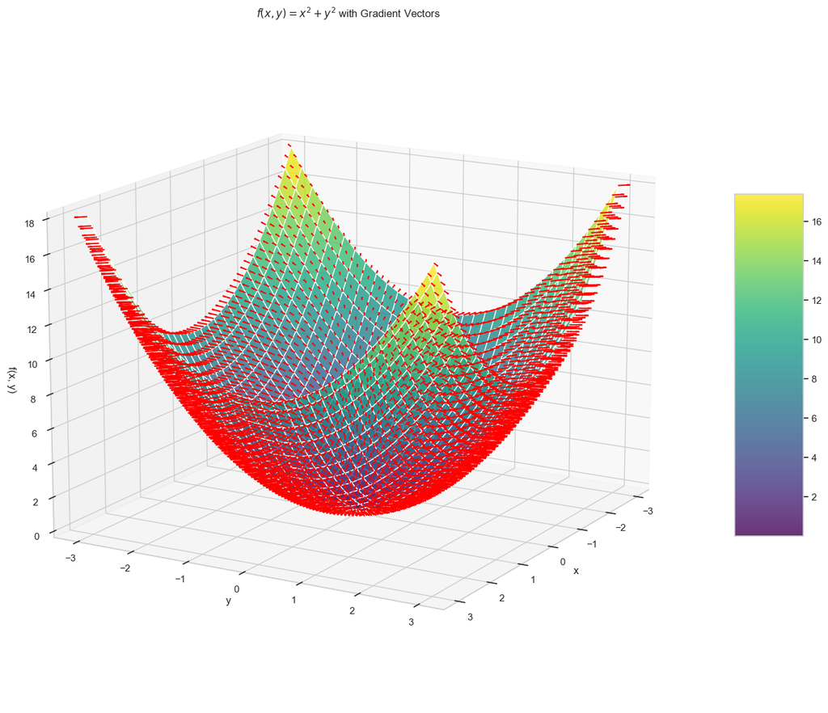

```python
# Create the 3D plot
fig = plt.figure(figsize=(18, 14))
ax = fig.add_subplot(111, projection='3d')

# Plot the surface
surf = ax.plot_surface(X, Y, Z1, cmap='viridis', alpha=0.8)

# Plot the gradient vectors
ax.quiver(X, Y, Z1, U1, V1, 0, color='red', length=0.2, normalize=True)

# Set labels
ax.set_title(r'$f(x, y) = x^2 + y^2$ with Gradient Vectors')
ax.set_xlabel('x')
ax.set_ylabel('y')
ax.set_zlabel('f(x, y)')

# Change the viewing angle
ax.view_init(elev=15, azim=30)
# ax.view_init(elev=180, azim=45)
# ax.view_init(elev=180, azim=90)

# Add a color bar which maps values to colors
fig.colorbar(surf, ax=ax, shrink=0.5, aspect=5)

plt.show()
```

## 3D Plot using Plotly

We create a 3D surface plot of the function $ f_1 \left(x,y\right) = x^2 + y^2 $ and overlay the gradient vectors. Gradient vectors are represented as cones with the appropriate lengths.

```python
# Create the 3D surface plot
surface = go.Surface(z=Z1, x=X, y=Y, colorscale='Viridis', opacity=0.8)

# Create the gradient vectors
quiver_x = X.flatten()
quiver_y = Y.flatten()
quiver_z = Z1.flatten()
quiver_u = U1.flatten()
quiver_v = V1.flatten()
quiver_w = np.zeros_like(U1).flatten()  # No change in z for the gradient vectors in this 2D function

quiver = go.Cone(x=quiver_x, y=quiver_y, z=quiver_z,
                 u=quiver_u, v=quiver_v, w=quiver_w,
                 colorscale='Reds', sizemode='scaled', sizeref=1.2, showscale=False)

# Create the figure and add the traces
fig = go.Figure(data=[surface, quiver])

# Set the layout
fig.update_layout(title='3D Surface Plot with Gradient Vectors',
                  scene=dict(
                      xaxis_title='X',
                      yaxis_title='Y',
                      zaxis_title='f(x, y)',
                      aspectratio=dict(x=1, y=1, z=0.5)
                  ),
                  width=1000, height=800)

fig.show()
```

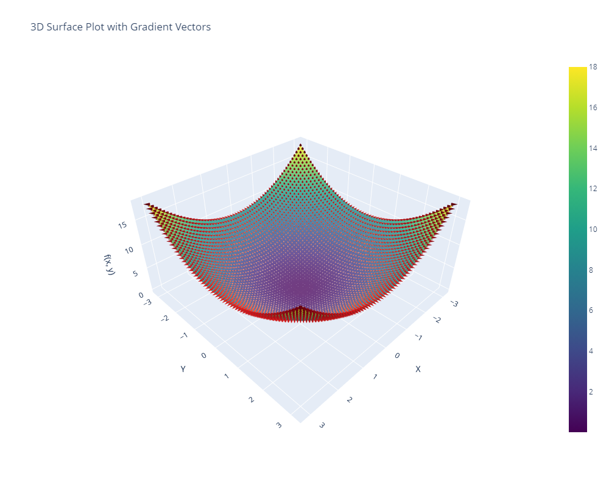

## 3D Plot using Plotly for Gradient vector field only

```python
# Create the gradient vectors
quiver_x = X.flatten()
quiver_y = Y.flatten()
quiver_z = Z1.flatten()
quiver_u = U1.flatten()
quiver_v = V1.flatten()
quiver_w = np.zeros_like(U1).flatten()  # No change in z for the gradient vectors in this 2D function

# quiver = go.Cone(x=quiver_x, y=quiver_y, z=quiver_z,
#                  u=quiver_u, v=quiver_v, w=quiver_w,
#                  colorscale='Reds', showscale=False)

# quiver = go.Cone(x=quiver_x, y=quiver_y, z=quiver_z,
#                  u=quiver_u, v=quiver_v, w=quiver_w,
#                  colorscale='Reds', sizemode='scaled', sizeref=0.5, showscale=False)

# quiver = go.Cone(x=quiver_x, y=quiver_y, z=quiver_z,
#                  u=quiver_u, v=quiver_v, w=quiver_w,
#                  colorscale='Reds', sizemode='absolute', sizeref=10, showscale=False)

quiver = go.Cone(x=quiver_x, y=quiver_y, z=quiver_z,
                 u=quiver_u, v=quiver_v, w=quiver_w,
                 colorscale='Viridis', sizemode='scaled', sizeref=1.2, showscale=True)

fig = go.Figure(data=[quiver])

# Set the layout with custom size
fig.update_layout(title='3D Surface Plot with Gradient Vectors',
                  scene=dict(
                      xaxis_title='X',
                      yaxis_title='Y',
                      zaxis_title='f(x, y)',
                      aspectratio=dict(x=1, y=1, z=0.5)
                  ),
                  width=1000,  # Custom width
                  height=700)  # Custom height

fig.show()
```

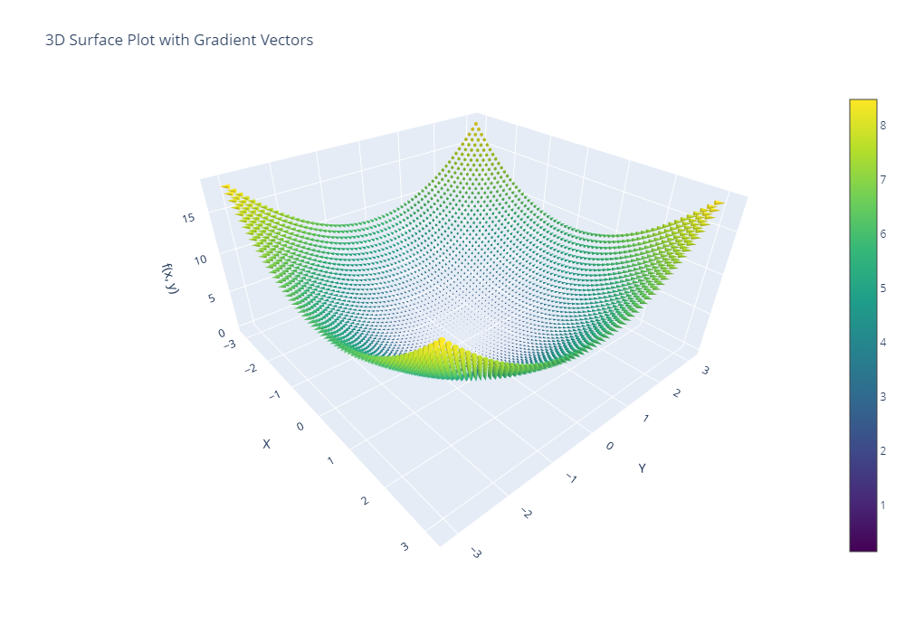

## 3D Plot using Plotly

We create a 3D surface plot of the function $ f_2 \left(x,y\right) = x^3 - 3 x y + y^3 $ and overlay the gradient vectors. Gradient vectors are represented as cones with the appropriate lengths.

```python
# Create the 3D surface plot
surface = go.Surface(z=Z2, x=X, y=Y, colorscale='Viridis', opacity=0.8)

# Create the gradient vectors
quiver_x = X.flatten()
quiver_y = Y.flatten()
quiver_z = Z2.flatten()
quiver_u = U2.flatten()
quiver_v = V2.flatten()
quiver_w = np.zeros_like(U2).flatten()  # No change in z for the gradient vectors in this 2D function

quiver = go.Cone(x=quiver_x, y=quiver_y, z=quiver_z,
                 u=quiver_u, v=quiver_v, w=quiver_w,
                 colorscale='Reds', sizemode='scaled', sizeref=1.2, showscale=False)

# Create the figure and add the traces
fig = go.Figure(data=[surface, quiver])

# Set the layout with custom size and HTML formatted title
fig.update_layout(title='3D Surface Plot with Gradient Vectors for f(x, y) = x<sup>3</sup> - 3xy + y<sup>3</sup>',
                  scene=dict(
                      xaxis_title='X',
                      yaxis_title='Y',
                      zaxis_title='f(x, y)',
                      aspectratio=dict(x=1, y=1, z=0.5)
                  ),
                  width=1000,  # Custom width
                  height=1000)  # Custom height

fig.show()
```

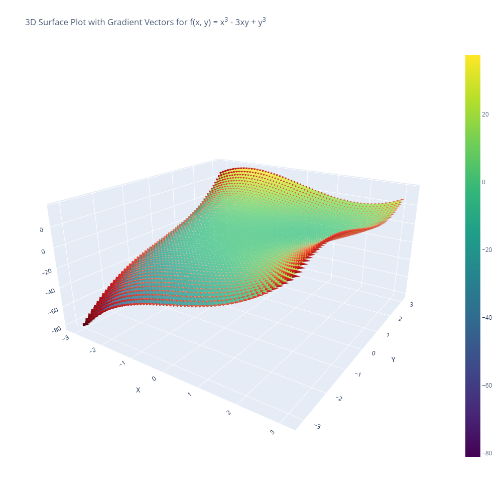